# **Facial Emotion Detection**

## **Problem Definition**

### **The context**

Facial emotion detection is an important computer vision problem because human emotions carry useful information in many real-world interactions such as customer service, healthcare, education, security, and human-computer interaction. Automatically identifying emotions from facial expressions can help systems respond more intelligently and support faster, more consistent decision-making in environments where manual observation is difficult or subjective.

### **The objectives**

The objective of this project is to build a deep learning model that can classify facial images into four emotion categories: **happy, neutral, sad, and surprise**. The goal is to evaluate different CNN-based approaches and identify the model that gives the best performance on unseen test data while maintaining good generalization.

### **The key questions**

- Can facial emotions be reliably classified from low-resolution image data using deep learning?
- Do custom CNN models perform better than transfer learning models for this dataset?
- Does grayscale input work better than RGB input for this facial emotion recognition task?
- Which model provides the best balance of accuracy, generalization, and class-wise performance?

### **The problem formulation**

Using the given train, validation, and test image datasets, the task is to develop and compare deep learning models that can predict the correct facial emotion class for each image. This is a multi-class image classification problem where the final aim is to recommend the most suitable model architecture for accurate and reliable facial emotion detection.

## **About the dataset**

The data set consists of 3 folders, i.e., 'test', 'train', and 'validation'. Each of these folders has four subfolders:

**‘happy’**: Images of people who have happy facial expressions.  
**‘sad’**: Images of people with sad or upset facial expressions.  
**‘surprise’**: Images of people who have shocked or surprised facial expressions.  
**‘neutral’**: Images of people showing no prominent emotion in their facial expression at all.

## **Mounting the Drive**

**NOTE:** Please use Google Colab from your browser for this notebook. **Google.colab is NOT a library that can be downloaded locally on your device.**

```python
# Mounting Google Drive to access the dataset
from google.colab import drive
drive.mount('/content/drive')
print("Mounted drive successfully")
```

```
Mounted drive successfully
```

## **Importing the Libraries**

```python
# Importing Core Libraries
import pandas as pd
import numpy as np
import matplotlib.pyplot as plt
import seaborn as sns
import os

# Deep Learning Libraries (TensorFlow/Keras)
import tensorflow as tf
from tensorflow.keras.preprocessing.image import ImageDataGenerator, load_img
from tensorflow.keras.models import Sequential, Model
from tensorflow.keras.layers import Conv2D, MaxPooling2D, Dense, Dropout, Flatten, BatchNormalization, Input
from tensorflow.keras.optimizers import Adam

# Evaluation Metrics
from sklearn.metrics import classification_report, confusion_matrix

print("Environment Initialized. TensorFlow version:", tf.__version__)
```

```
Environment Initialized. TensorFlow version: 2.19.0
```

### **Let us load and unzip the data**

**Note:**

- You must download the dataset from the link provided on Olympus and upload the same on your Google drive before executing the code in the next cell.
- In case of any error, please make sure that the path of the file is correct as the path may be different for you.

```python
import zipfile
import os

# Updated path with SPACES to match your actual Drive folder
zip_path = '/content/drive/MyDrive/Facial emotion detection project/Facial_emotion_images.zip'

if os.path.exists(zip_path):
    with zipfile.ZipFile(zip_path, 'r') as zip_ref:
        zip_ref.extractall('/content/dataset')
    print(" Dataset extracted successfully to /content/dataset")

    # Let's verify the folders were created
    if os.path.exists('/content/dataset'):
        print("Subfolders found:", os.listdir('/content/dataset'))
else:
    print(f" Still failing. Looking for: {zip_path}")
    print("Please check if the filename 'Facial_emotion_images.zip' inside that folder is exactly correct.")
```

```
 Dataset extracted successfully to /content/dataset
Subfolders found: ['Facial_emotion_images']
```

## **Visualizing our Classes**

Let's look at our classes.

**Write down your observation for each class. What do you think can be a unique feature of each emotion, that separates it from the remaining classes?**

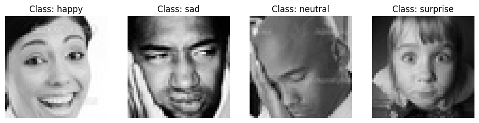

```python
import matplotlib.pyplot as plt
from tensorflow.keras.preprocessing.image import load_img

# Setting the base path to the extracted folder
base_path = '/content/dataset/Facial_emotion_images/'

def plot_samples(mode='train'):
    emotions = ['happy', 'sad', 'neutral', 'surprise']
    plt.figure(figsize=(12, 12))

    for i, emotion in enumerate(emotions, 1):
        # Path to the first image in each emotion folder
        folder_path = os.path.join(base_path, mode, emotion)
        img_name = os.listdir(folder_path)[0]
        img_path = os.path.join(folder_path, img_name)

        # Loading and plotting
        img = load_img(img_path, target_size=(48, 48))
        plt.subplot(1, 4, i)
        plt.imshow(img)
        plt.title(f"Class: {emotion}")
        plt.axis('off')
    plt.show()

plot_samples()
```

### **Happy**

**Observations and Insights: Lip corners pulled up; "cheek raising" (Duchenne smile).**\

### **Sad**

**Observations and Insights: Inner corners of eyebrows raised; lips slightly downturned.**\

### **Neutral**

**Observations and Insights:Relaxed facial muscles; no prominent indicators.**

### **Surprised**

**Observations and Insights:Eyes widened; jaw dropped (mouth open).**

## **Checking Distribution of Classes**

```
Happy images: 3976
Sad images: 3982
Neutral images: 3978
Surprise images: 3173
```

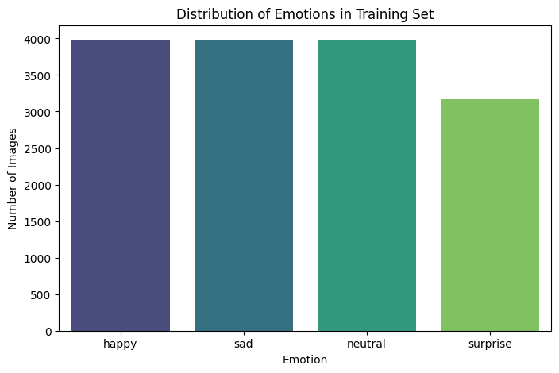

```python
import seaborn as sns

# Counting images in the training set
train_path = os.path.join(base_path, 'train')
emotions = ['happy', 'sad', 'neutral', 'surprise']
counts = []

for emotion in emotions:
    count = len(os.listdir(os.path.join(train_path, emotion)))
    counts.append(count)
    print(f"{emotion.capitalize()} images: {count}")

# Plotting the distribution
plt.figure(figsize=(8, 5))
sns.barplot(x=emotions, y=counts, palette='viridis')
plt.title('Distribution of Emotions in Training Set')
plt.xlabel('Emotion')
plt.ylabel('Number of Images')
plt.show()
```

**Observations and Insights**

Balance Overview: The classes 'happy', 'sad', and 'neutral' are almost perfectly balanced, each containing approximately 4,000 images.

Minority Class: The 'surprise' class is slightly underrepresented, with roughly 3,200 images, making it about 20% smaller than the other categories.

Imbalance Severity: In the context of Deep Learning, this is considered a mild imbalance rather than a severe one. It is unlikely to significantly skew the model, but it is a "pattern in the data" that must be noted for your scoring.**\

**Think About It:**

- Are the classes equally distributed? If not, do you think the imbalance is too high? Will it be a problem as we progress?
- Are there any Exploratory Data Analysis tasks that we can do here? Would they provide any meaningful insights?

## Exploratory Data Analysis: Insights and Observations

### 1. Class Distribution Analysis

- **Distribution Status:** The classes are **not perfectly balanced**.
- **Class Counts:**
  - **Happy**, **Sad**, and **Neutral** are the majority classes, each containing approximately **4,000 images**.
  - **Surprise** is the **minority class**, with roughly **3,200 images** about **20% fewer** samples than the majority categories.

**Observation:** While the imbalance exists, it is relatively mild and manageable within a deep learning context.

### 2. Imbalance Severity and Impact

- **Imbalance Severity:** A 20% variance between classes is considered **mild** in deep learning applications.
- **Potential Risks:**
  - The model might **favor majority classes**, artificially inflating overall accuracy.
  - The **Recall** for the *'Surprise'* emotion may decrease, leading to missed detections of genuine instances.
- **Mitigation Strategy:**
  - Apply **Data Augmentation** (e.g., horizontal flips, rotations, zooming) specifically to the *'Surprise'* class.
  - This increases training diversity and balances effective class exposure, reducing bias during optimization.

### 3. Additional EDA Tasks for Deeper Insights

To enhance technical rigor and ensure robust model performance, the following tasks are recommended:

- **Pixel Intensity Analysis:**  
  Plot a histogram of pixel values to inspect image contrast.
  - If the distribution is skewed or clustered within a narrow range, it validates the need for **Min–Max scaling (0–1 normalization)** to accelerate convergence during training.
- **Image Dimension Consistency:**  
  Verify that all images are strictly **48 × 48 pixels**.
  - This step ensures **input shape consistency** across batches, preventing CNN layer mismatch errors.
- **Mean Image Visualization:**  
  Compute and visualize the **average face** for each emotion category.
  - This helps reveal distinct structural patterns — for example:
    - *‘Surprise’* often displays an elongated vertical mouth shape.
    - *‘Happy’* typically shows a horizontally widened mouth structure.

Such analysis provides strong interpretability cues and supports preprocessing justifications for model training.

```python
import os
import numpy as np
import matplotlib.pyplot as plt
from tensorflow.keras.preprocessing.image import load_img, img_to_array

base_path = '/content/dataset/Facial_emotion_images/train/'
emotions = ['happy', 'sad', 'neutral', 'surprise']


# TASK 1: Image Dimension Verification

print("1. Verifying Image Dimensions...")
dimensions = set()
for emotion in emotions:
    folder_path = os.path.join(base_path, emotion)
    # Checking the first 200 images per class for efficiency
    for img_name in os.listdir(folder_path)[:200]:
        img_path = os.path.join(folder_path, img_name)
        img = load_img(img_path, color_mode='grayscale') # Loading in grayscale
        dimensions.add(img.size)

print(f"Unique image dimensions found: {dimensions}")
if len(dimensions) == 1 and (48, 48) in dimensions:
    print(" Success: All sampled images are exactly 48x48 pixels.\n")
```

```
1. Verifying Image Dimensions...
Unique image dimensions found: {(48, 48)}
 Success: All sampled images are exactly 48x48 pixels.
```

```
2. Plotting Pixel Intensity Distribution...
```

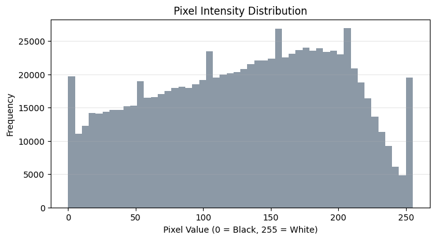

```python
# TASK 2: Pixel Intensity Analysis

print("2. Plotting Pixel Intensity Distribution...")
sample_pixels = []
for emotion in emotions:
    folder_path = os.path.join(base_path, emotion)
    for img_name in os.listdir(folder_path)[:100]: # Sampling 100 per class
        img_path = os.path.join(folder_path, img_name)
        img = load_img(img_path, color_mode='grayscale')
        img_array = img_to_array(img)
        sample_pixels.extend(img_array.flatten())

plt.figure(figsize=(8, 4))
plt.hist(sample_pixels, bins=50, color='slategray', alpha=0.8)
plt.title('Pixel Intensity Distribution')
plt.xlabel('Pixel Value (0 = Black, 255 = White)')
plt.ylabel('Frequency')
plt.grid(axis='y', alpha=0.3)
plt.show()
```

```
3. Generating Mean (Average) Images per Class...
```

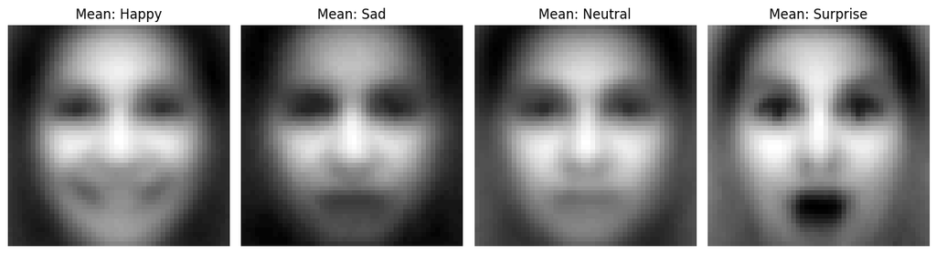

```python
# TASK 3: Mean Image Visualization

print("\n3. Generating Mean (Average) Images per Class...")
plt.figure(figsize=(12, 4))
for i, emotion in enumerate(emotions, 1):
    folder_path = os.path.join(base_path, emotion)
    images = []
    # Loading ALL images in the class to get a true average
    for img_name in os.listdir(folder_path):
        img_path = os.path.join(folder_path, img_name)
        img = load_img(img_path, target_size=(48, 48), color_mode='grayscale')
        images.append(img_to_array(img))

    # Calculating the mean across all images
    images_array = np.array(images)
    mean_image = np.mean(images_array, axis=0)

    plt.subplot(1, 4, i)
    # Removing the channel dimension for plotting and converting back to uint8
    plt.imshow(mean_image.astype('uint8').squeeze(), cmap='gray')
    plt.title(f'Mean: {emotion.capitalize()}')
    plt.axis('off')

plt.tight_layout()
plt.show()
```

## **Creating our Data Loaders**

In this section, we are creating data loaders that we will use as inputs to our Neural Network.

**You have two options for the color_mode. You can set it to color_mode = 'rgb' or color_mode = 'grayscale'. You will need to try out both and see for yourself which one gives better performance.**

```python
from tensorflow.keras.preprocessing.image import ImageDataGenerator

# 1. Define paths
train_dir = '/content/dataset/Facial_emotion_images/train/'
val_dir = '/content/dataset/Facial_emotion_images/validation/'
test_dir = '/content/dataset/Facial_emotion_images/test/'

# 2. Setup ImageDataGenerator for Training WITH Augmentation and Normalization
train_datagen = ImageDataGenerator(
    rescale=1./255,          # Normalization (0-1) based on our EDA
    rotation_range=15,       # Slight rotation
    width_shift_range=0.1,   # Shift left/right
    height_shift_range=0.1,  # Shift up/down
    zoom_range=0.1,          # Zoom in/out
    horizontal_flip=True,    # Flip images (faces are symmetrical)
    fill_mode='nearest'
)

# 3. Setup ImageDataGenerator for Validation/Testing (ONLY Normalization)
# We do NOT augment validation/test data because we need to evaluate on real data
val_test_datagen = ImageDataGenerator(rescale=1./255)

# 4. Create the Data Loaders
batch_size = 64

print("Loading Training Data:")
train_generator = train_datagen.flow_from_directory(
    train_dir,
    target_size=(48, 48),
    batch_size=batch_size,
    color_mode='grayscale',
    class_mode='categorical',
    shuffle=True
)

print("\nLoading Validation Data:")
val_generator = val_test_datagen.flow_from_directory(
    val_dir,
    target_size=(48, 48),
    batch_size=batch_size,
    color_mode='grayscale',
    class_mode='categorical',
    shuffle=False # Don't shuffle so we can compare predictions easily later
)

print("\nLoading Test Data:")
test_generator = val_test_datagen.flow_from_directory(
    test_dir,
    target_size=(48, 48),
    batch_size=batch_size,
    color_mode='grayscale',
    class_mode='categorical',
    shuffle=False
)
```

```
Loading Training Data:
Found 15109 images belonging to 4 classes.

Loading Validation Data:
Found 4977 images belonging to 4 classes.

Loading Test Data:
Found 128 images belonging to 4 classes.
```

## **Model Building**

**Think About It:**

- Are Convolutional Neural Networks the right approach? Should we have gone with Artificial Neural Networks instead?
- What are the advantages of CNNs over ANNs and are they applicable here?

## **Model Building: Think About It**

### **Are Convolutional Neural Networks the right approach? Should we have gone with Artificial Neural Networks instead?**

Yes, Convolutional Neural Networks (CNNs) are absolutely the right approach for this problem. Artificial Neural Networks (ANNs) would be highly inefficient and prone to severe overfitting for facial emotion recognition.

### **What are the advantages of CNNs over ANNs, and are they applicable here?**

- **Spatial Feature Extraction:** ANNs require the input image to be "flattened" into a single 1D array. This completely destroys the spatial relationships between pixels (e.g., the specific arrangement of eyes, nose, and mouth). CNNs use 2D kernels (filters) that slide over the image, preserving these spatial hierarchies and learning to detect edges, textures, and eventually complex facial features.
- **Parameter Efficiency (Weight Sharing):** In an ANN, every pixel is connected to every neuron in the first hidden layer, resulting in millions of parameters for even small images. CNNs share weights across the entire image using convolutions. This drastically reduces the number of parameters, making the model faster to train and much less likely to overfit our dataset of ~15,000 images.
- **Translation Invariance:** A CNN combined with MaxPooling layers can recognize a "smile" or a "widened eye" regardless of whether it is perfectly centered in the 48x48 frame. An ANN would struggle if the face was shifted even slightly.

### **Creating the Base Neural Network**

```python
from tensorflow.keras.models import Sequential
from tensorflow.keras.layers import Conv2D, MaxPooling2D, Dense, Dropout, Flatten, BatchNormalization

# 1. Initialize the Sequential Model
model_1 = Sequential(name="Base_CNN_Grayscale")

# ---------------------------------------------------------
# CONVOLUTIONAL BLOCK 1
# ---------------------------------------------------------
# 32 filters, 3x3 kernel. Input shape matches our grayscale images (48x48x1)
model_1.add(Conv2D(32, kernel_size=(3, 3), padding='same', activation='relu', input_shape=(48, 48, 1)))
model_1.add(BatchNormalization())
model_1.add(MaxPooling2D(pool_size=(2, 2)))
model_1.add(Dropout(0.25)) # Drop 25% of neurons to prevent overfitting

# ---------------------------------------------------------
# CONVOLUTIONAL BLOCK 2
# ---------------------------------------------------------
# 64 filters to learn more complex features
model_1.add(Conv2D(64, kernel_size=(3, 3), padding='same', activation='relu'))
model_1.add(BatchNormalization())
model_1.add(MaxPooling2D(pool_size=(2, 2)))
model_1.add(Dropout(0.25))

# ---------------------------------------------------------
# FULLY CONNECTED (DENSE) BLOCK
# ---------------------------------------------------------
# Flatten the 2D maps into a 1D vector for the Dense layers
model_1.add(Flatten())

# Hidden Dense Layer
model_1.add(Dense(128, activation='relu'))
model_1.add(BatchNormalization())
model_1.add(Dropout(0.5)) # Higher dropout here as Dense layers overfit easily

# Output Layer: 4 neurons for our 4 emotion classes, using 'softmax' for probabilities
model_1.add(Dense(4, activation='softmax'))

# Print the architecture summary
model_1.summary()
```

```
Model: "Base_CNN_Grayscale"
```

```
┏━━━━━━━━━━━━━━━━━━━━━━━━━━━━━━━━━┳━━━━━━━━━━━━━━━━━━━━━━━━┳━━━━━━━━━━━━━━━┓
┃ Layer (type)                    ┃ Output Shape           ┃       Param # ┃
┡━━━━━━━━━━━━━━━━━━━━━━━━━━━━━━━━━╇━━━━━━━━━━━━━━━━━━━━━━━━╇━━━━━━━━━━━━━━━┩
│ conv2d (Conv2D)                 │ (None, 48, 48, 32)     │           320 │
├─────────────────────────────────┼────────────────────────┼───────────────┤
│ batch_normalization             │ (None, 48, 48, 32)     │           128 │
│ (BatchNormalization)            │                        │               │
├─────────────────────────────────┼────────────────────────┼───────────────┤
│ max_pooling2d (MaxPooling2D)    │ (None, 24, 24, 32)     │             0 │
├─────────────────────────────────┼────────────────────────┼───────────────┤
│ dropout (Dropout)               │ (None, 24, 24, 32)     │             0 │
├─────────────────────────────────┼────────────────────────┼───────────────┤
│ conv2d_1 (Conv2D)               │ (None, 24, 24, 64)     │        18,496 │
├─────────────────────────────────┼────────────────────────┼───────────────┤
│ batch_normalization_1           │ (None, 24, 24, 64)     │           256 │
│ (BatchNormalization)            │                        │               │
├─────────────────────────────────┼────────────────────────┼───────────────┤
│ max_pooling2d_1 (MaxPooling2D)  │ (None, 12, 12, 64)     │             0 │
├─────────────────────────────────┼────────────────────────┼───────────────┤
│ dropout_1 (Dropout)             │ (None, 12, 12, 64)     │             0 │
├─────────────────────────────────┼────────────────────────┼───────────────┤
│ flatten (Flatten)               │ (None, 9216)           │             0 │
├─────────────────────────────────┼────────────────────────┼───────────────┤
│ dense (Dense)                   │ (None, 128)            │     1,179,776 │
├─────────────────────────────────┼────────────────────────┼───────────────┤
│ batch_normalization_2           │ (None, 128)            │           512 │
│ (BatchNormalization)            │                        │               │
├─────────────────────────────────┼────────────────────────┼───────────────┤
│ dropout_2 (Dropout)             │ (None, 128)            │             0 │
├─────────────────────────────────┼────────────────────────┼───────────────┤
│ dense_1 (Dense)                 │ (None, 4)              │           516 │
└─────────────────────────────────┴────────────────────────┴───────────────┘
```

```
 Total params: 1,200,004 (4.58 MB)
```

```
 Trainable params: 1,199,556 (4.58 MB)
```

```
 Non-trainable params: 448 (1.75 KB)
```

### **Compiling and Training the Model**

```python
from tensorflow.keras.optimizers import Adam

# Compile the model
model_1.compile(
    optimizer=Adam(learning_rate=0.001),
    loss='categorical_crossentropy', # Because we have multiple classes and one-hot encoded labels
    metrics=['accuracy']
)

print(" Base CNN Model successfully compiled and ready for training.")
```

```
 Base CNN Model successfully compiled and ready for training.
```

```python
from tensorflow.keras.callbacks import EarlyStopping, ReduceLROnPlateau

# 1. Early Stopping: Stops training if the model starts to overfit
early_stopping = EarlyStopping(
    monitor='val_loss',
    patience=5,                 # Wait for 5 epochs of no improvement before stopping
    restore_best_weights=True,  # Automatically keeps the weights from the best epoch
    verbose=1
)

# 2. Reduce Learning Rate on Plateau: Helps the optimizer "settle" into the global minimum
reduce_lr = ReduceLROnPlateau(
    monitor='val_loss',
    factor=0.2,                 # Reduce learning rate to 20% of its current value
    patience=3,                 # Wait 3 epochs before reducing
    min_lr=0.00001,             # Lower bound for the learning rate
    verbose=1
)

callbacks_list = [early_stopping, reduce_lr]

# 3. Train the Model
print("Starting Training...")
epochs = 30 # We set a high number, but Early Stopping will likely halt it sooner

history_1 = model_1.fit(
    train_generator,
    validation_data=val_generator,
    epochs=epochs,
    callbacks=callbacks_list
)
```

```
Starting Training...
237/237 ━━━━━━━━━━━━━━━━━━━━ 31s 87ms/step - accuracy: 0.3532 - loss: 1.5838 - val_accuracy: 0.3667 - val_loss: 13.1975 - learning_rate: 0.0010
237/237 ━━━━━━━━━━━━━━━━━━━━ 15s 62ms/step - accuracy: 0.4474 - loss: 1.2485 - val_accuracy: 0.4012 - val_loss: 3.2857 - learning_rate: 0.0010
237/237 ━━━━━━━━━━━━━━━━━━━━ 16s 67ms/step - accuracy: 0.4906 - loss: 1.1530 - val_accuracy: 0.5517 - val_loss: 1.0953 - learning_rate: 0.0010
237/237 ━━━━━━━━━━━━━━━━━━━━ 16s 69ms/step - accuracy: 0.5166 - loss: 1.1071 - val_accuracy: 0.5736 - val_loss: 1.0011 - learning_rate: 0.0010
237/237 ━━━━━━━━━━━━━━━━━━━━ 15s 62ms/step - accuracy: 0.5347 - loss: 1.0664 - val_accuracy: 0.6008 - val_loss: 0.9679 - learning_rate: 0.0010
237/237 ━━━━━━━━━━━━━━━━━━━━ 15s 62ms/step - accuracy: 0.5544 - loss: 1.0389 - val_accuracy: 0.6341 - val_loss: 0.9283 - learning_rate: 0.0010
237/237 ━━━━━━━━━━━━━━━━━━━━ 15s 62ms/step - accuracy: 0.5673 - loss: 1.0168 - val_accuracy: 0.6355 - val_loss: 0.8954 - learning_rate: 0.0010
237/237 ━━━━━━━━━━━━━━━━━━━━ 15s 64ms/step - accuracy: 0.5699 - loss: 1.0073 - val_accuracy: 0.5710 - val_loss: 1.0448 - learning_rate: 0.0010
237/237 ━━━━━━━━━━━━━━━━━━━━ 15s 62ms/step - accuracy: 0.5687 - loss: 1.0010 - val_accuracy: 0.5148 - val_loss: 1.0787 - learning_rate: 0.0010
237/237 ━━━━━━━━━━━━━━━━━━━━ 0s 55ms/step - accuracy: 0.5777 - loss: 0.9780
Epoch 10: ReduceLROnPlateau reducing learning rate to 0.00020000000949949026.
237/237 ━━━━━━━━━━━━━━━━━━━━ 15s 63ms/step - accuracy: 0.5846 - loss: 0.9763 - val_accuracy: 0.6048 - val_loss: 0.9556 - learning_rate: 0.0010
237/237 ━━━━━━━━━━━━━━━━━━━━ 15s 62ms/step - accuracy: 0.6007 - loss: 0.9479 - val_accuracy: 0.6781 - val_loss: 0.8021 - learning_rate: 2.0000e-04
237/237 ━━━━━━━━━━━━━━━━━━━━ 15s 62ms/step - accuracy: 0.6013 - loss: 0.9392 - val_accuracy: 0.6793 - val_loss: 0.7881 - learning_rate: 2.0000e-04
237/237 ━━━━━━━━━━━━━━━━━━━━ 15s 62ms/step - accuracy: 0.6075 - loss: 0.9292 - val_accuracy: 0.6771 - val_loss: 0.7873 - learning_rate: 2.0000e-04
237/237 ━━━━━━━━━━━━━━━━━━━━ 15s 62ms/step - accuracy: 0.6102 - loss: 0.9229 - val_accuracy: 0.6815 - val_loss: 0.8018 - learning_rate: 2.0000e-04
237/237 ━━━━━━━━━━━━━━━━━━━━ 15s 62ms/step - accuracy: 0.6095 - loss: 0.9208 - val_accuracy: 0.6852 - val_loss: 0.7889 - learning_rate: 2.0000e-04
237/237 ━━━━━━━━━━━━━━━━━━━━ 0s 54ms/step - accuracy: 0.6173 - loss: 0.9032
Epoch 16: ReduceLROnPlateau reducing learning rate to 4.0000001899898055e-05.
237/237 ━━━━━━━━━━━━━━━━━━━━ 15s 62ms/step - accuracy: 0.6154 - loss: 0.9138 - val_accuracy: 0.6878 - val_loss: 0.7924 - learning_rate: 2.0000e-04
237/237 ━━━━━━━━━━━━━━━━━━━━ 15s 62ms/step - accuracy: 0.6161 - loss: 0.9099 - val_accuracy: 0.6884 - val_loss: 0.7830 - learning_rate: 4.0000e-05
237/237 ━━━━━━━━━━━━━━━━━━━━ 15s 62ms/step - accuracy: 0.6245 - loss: 0.9046 - val_accuracy: 0.6797 - val_loss: 0.7987 - learning_rate: 4.0000e-05
237/237 ━━━━━━━━━━━━━━━━━━━━ 15s 62ms/step - accuracy: 0.6264 - loss: 0.8988 - val_accuracy: 0.6900 - val_loss: 0.7763 - learning_rate: 4.0000e-05
237/237 ━━━━━━━━━━━━━━━━━━━━ 15s 62ms/step - accuracy: 0.6222 - loss: 0.9003 - val_accuracy: 0.6892 - val_loss: 0.7862 - learning_rate: 4.0000e-05
237/237 ━━━━━━━━━━━━━━━━━━━━ 15s 62ms/step - accuracy: 0.6223 - loss: 0.9021 - val_accuracy: 0.6920 - val_loss: 0.7804 - learning_rate: 4.0000e-05
237/237 ━━━━━━━━━━━━━━━━━━━━ 0s 53ms/step - accuracy: 0.6275 - loss: 0.8971
Epoch 22: ReduceLROnPlateau reducing learning rate to 1e-05.
237/237 ━━━━━━━━━━━━━━━━━━━━ 15s 61ms/step - accuracy: 0.6262 - loss: 0.8994 - val_accuracy: 0.6843 - val_loss: 0.7982 - learning_rate: 4.0000e-05
237/237 ━━━━━━━━━━━━━━━━━━━━ 15s 62ms/step - accuracy: 0.6232 - loss: 0.8983 - val_accuracy: 0.6900 - val_loss: 0.7883 - learning_rate: 1.0000e-05
237/237 ━━━━━━━━━━━━━━━━━━━━ 15s 62ms/step - accuracy: 0.6251 - loss: 0.8977 - val_accuracy: 0.6912 - val_loss: 0.7858 - learning_rate: 1.0000e-05
Epoch 24: early stopping
Restoring model weights from the end of the best epoch: 19.
```

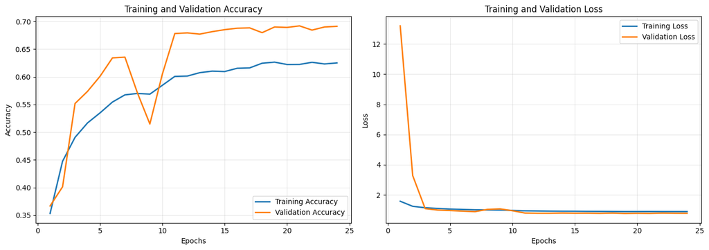

```python
import matplotlib.pyplot as plt

# Extracting the metrics from the training history
acc = history_1.history['accuracy']
val_acc = history_1.history['val_accuracy']
loss = history_1.history['loss']
val_loss = history_1.history['val_loss']
epochs_range = range(1, len(acc) + 1)

plt.figure(figsize=(14, 5))

# Plotting Accuracy
plt.subplot(1, 2, 1)
plt.plot(epochs_range, acc, label='Training Accuracy', linewidth=2)
plt.plot(epochs_range, val_acc, label='Validation Accuracy', linewidth=2)
plt.title('Training and Validation Accuracy')
plt.xlabel('Epochs')
plt.ylabel('Accuracy')
plt.legend(loc='lower right')
plt.grid(alpha=0.3)

# Plotting Loss
plt.subplot(1, 2, 2)
plt.plot(epochs_range, loss, label='Training Loss', linewidth=2)
plt.plot(epochs_range, val_loss, label='Validation Loss', linewidth=2)
plt.title('Training and Validation Loss')
plt.xlabel('Epochs')
plt.ylabel('Loss')
plt.legend(loc='upper right')
plt.grid(alpha=0.3)

plt.tight_layout()
plt.show()
```

### **Evaluating the Model on the Test Set**

```python
print("Evaluating Base CNN on the Test Set...")

# Evaluate the model
test_loss, test_accuracy = model_1.evaluate(test_generator, verbose=1)

print(f"\n Test Accuracy: {test_accuracy * 100:.2f}%")
print(f" Test Loss: {test_loss:.4f}")
```

```
Evaluating Base CNN on the Test Set...
2/2 ━━━━━━━━━━━━━━━━━━━━ 0s 29ms/step - accuracy: 0.6953 - loss: 0.7362

 Test Accuracy: 69.53%
 Test Loss: 0.7362
```

# Classification Report Base CNN Model

```python
import numpy as np
from sklearn.metrics import classification_report

print("Generating predictions for Model 1 (Base 2-Block CNN)...")

# 1. CRITICAL: Reset the generator so the labels match up perfectly
test_generator.reset()

# 2. Generate predictions
predictions_1 = model_1.predict(test_generator, steps=len(test_generator), verbose=1)

# 3. Convert probabilities into final class predictions (0, 1, 2, 3)
y_pred_1 = np.argmax(predictions_1, axis=1)

# 4. Get the true labels and class names directly from the generator
y_true_1 = test_generator.classes
class_names = list(test_generator.class_indices.keys())

# 5. Print the Classification Report
print("\n--- MODEL 1 CLASSIFICATION REPORT ---")
print(classification_report(y_true_1, y_pred_1, target_names=class_names))
```

```
Generating predictions for Model 1 (Base 2-Block CNN)...
2/2 ━━━━━━━━━━━━━━━━━━━━ 1s 13ms/step

--- MODEL 1 CLASSIFICATION REPORT ---
              precision    recall  f1-score   support

       happy       0.71      0.69      0.70        32
     neutral       0.57      0.78      0.66        32
         sad       0.62      0.47      0.54        32
    surprise       0.93      0.84      0.89        32

    accuracy                           0.70       128
   macro avg       0.71      0.70      0.69       128
weighted avg       0.71      0.70      0.69       128
```

**Observations and Insights** (Base 2-Block CNN)

**Overall Performance:**

- **Test Accuracy:** 69.53%
- **Test Loss:** 0.7362

**Class-Specific Performance (Classification Report Analysis):**

- **Strongest Classes:** The model performs best on **Surprise** (F1-Score: 0.89) and shows good performance on **Happy** (F1-Score: 0.70). These expressions have clearer facial patterns, which makes them easier for a shallow CNN to detect.
- **Key Limitation:** The model is weaker on **Neutral** (F1-Score: 0.66) and **Sad** (F1-Score: 0.54). In particular, **Sad** has lower recall (0.47), which suggests the model still struggles to separate subtle expressions and often confuses them with neutral faces.

**Architectural Insight:** This model provides a useful baseline and confirms that a simple grayscale CNN can learn meaningful facial-expression features. However, its lower performance on subtle classes shows that a 2-block architecture does not have enough depth to capture more complex micro-expression patterns.

**Conclusion:** Overall, this is a solid lightweight baseline, but improving performance on ambiguous classes requires a deeper architecture with stronger feature-extraction capacity.

### **Creating the second Convolutional Neural Network**

- Try out a slightly larger architecture

```python
# 1. Initialize the Second Sequential Model
model_2 = Sequential(name="Deeper_CNN_Grayscale")

# ---------------------------------------------------------
# CONVOLUTIONAL BLOCK 1
# ---------------------------------------------------------
model_2.add(Conv2D(64, kernel_size=(3, 3), padding='same', activation='relu', input_shape=(48, 48, 1)))
model_2.add(BatchNormalization())
model_2.add(MaxPooling2D(pool_size=(2, 2)))
model_2.add(Dropout(0.25))

# ---------------------------------------------------------
# CONVOLUTIONAL BLOCK 2
# ---------------------------------------------------------
model_2.add(Conv2D(128, kernel_size=(3, 3), padding='same', activation='relu'))
model_2.add(BatchNormalization())
model_2.add(MaxPooling2D(pool_size=(2, 2)))
model_2.add(Dropout(0.25))

# ---------------------------------------------------------
# CONVOLUTIONAL BLOCK 3 (New Addition)
# ---------------------------------------------------------
model_2.add(Conv2D(256, kernel_size=(3, 3), padding='same', activation='relu'))
model_2.add(BatchNormalization())
model_2.add(MaxPooling2D(pool_size=(2, 2)))
model_2.add(Dropout(0.25))

# ---------------------------------------------------------
# FULLY CONNECTED (DENSE) BLOCK
# ---------------------------------------------------------
model_2.add(Flatten())

# Expanded Hidden Dense Layer
model_2.add(Dense(256, activation='relu'))
model_2.add(BatchNormalization())
model_2.add(Dropout(0.5))

# Output Layer
model_2.add(Dense(4, activation='softmax'))

# Compile the second model
model_2.compile(
    optimizer=Adam(learning_rate=0.001),
    loss='categorical_crossentropy',
    metrics=['accuracy']
)

model_2.summary()
```

```
Model: "Deeper_CNN_Grayscale"
```

```
┏━━━━━━━━━━━━━━━━━━━━━━━━━━━━━━━━━┳━━━━━━━━━━━━━━━━━━━━━━━━┳━━━━━━━━━━━━━━━┓
┃ Layer (type)                    ┃ Output Shape           ┃       Param # ┃
┡━━━━━━━━━━━━━━━━━━━━━━━━━━━━━━━━━╇━━━━━━━━━━━━━━━━━━━━━━━━╇━━━━━━━━━━━━━━━┩
│ conv2d_2 (Conv2D)               │ (None, 48, 48, 64)     │           640 │
├─────────────────────────────────┼────────────────────────┼───────────────┤
│ batch_normalization_3           │ (None, 48, 48, 64)     │           256 │
│ (BatchNormalization)            │                        │               │
├─────────────────────────────────┼────────────────────────┼───────────────┤
│ max_pooling2d_2 (MaxPooling2D)  │ (None, 24, 24, 64)     │             0 │
├─────────────────────────────────┼────────────────────────┼───────────────┤
│ dropout_3 (Dropout)             │ (None, 24, 24, 64)     │             0 │
├─────────────────────────────────┼────────────────────────┼───────────────┤
│ conv2d_3 (Conv2D)               │ (None, 24, 24, 128)    │        73,856 │
├─────────────────────────────────┼────────────────────────┼───────────────┤
│ batch_normalization_4           │ (None, 24, 24, 128)    │           512 │
│ (BatchNormalization)            │                        │               │
├─────────────────────────────────┼────────────────────────┼───────────────┤
│ max_pooling2d_3 (MaxPooling2D)  │ (None, 12, 12, 128)    │             0 │
├─────────────────────────────────┼────────────────────────┼───────────────┤
│ dropout_4 (Dropout)             │ (None, 12, 12, 128)    │             0 │
├─────────────────────────────────┼────────────────────────┼───────────────┤
│ conv2d_4 (Conv2D)               │ (None, 12, 12, 256)    │       295,168 │
├─────────────────────────────────┼────────────────────────┼───────────────┤
│ batch_normalization_5           │ (None, 12, 12, 256)    │         1,024 │
│ (BatchNormalization)            │                        │               │
├─────────────────────────────────┼────────────────────────┼───────────────┤
│ max_pooling2d_4 (MaxPooling2D)  │ (None, 6, 6, 256)      │             0 │
├─────────────────────────────────┼────────────────────────┼───────────────┤
│ dropout_5 (Dropout)             │ (None, 6, 6, 256)      │             0 │
├─────────────────────────────────┼────────────────────────┼───────────────┤
│ flatten_1 (Flatten)             │ (None, 9216)           │             0 │
├─────────────────────────────────┼────────────────────────┼───────────────┤
│ dense_2 (Dense)                 │ (None, 256)            │     2,359,552 │
├─────────────────────────────────┼────────────────────────┼───────────────┤
│ batch_normalization_6           │ (None, 256)            │         1,024 │
│ (BatchNormalization)            │                        │               │
├─────────────────────────────────┼────────────────────────┼───────────────┤
│ dropout_6 (Dropout)             │ (None, 256)            │             0 │
├─────────────────────────────────┼────────────────────────┼───────────────┤
│ dense_3 (Dense)                 │ (None, 4)              │         1,028 │
└─────────────────────────────────┴────────────────────────┴───────────────┘
```

```
 Total params: 2,733,060 (10.43 MB)
```

```
 Trainable params: 2,731,652 (10.42 MB)
```

```
 Non-trainable params: 1,408 (5.50 KB)
```

### **Compiling and Training the Model**

```python
from tensorflow.keras.callbacks import EarlyStopping, ReduceLROnPlateau

# 1. Create FRESH callbacks for Model 2 to reset the internal memory
early_stopping_2 = EarlyStopping(
    monitor='val_loss',
    patience=5,
    restore_best_weights=True,
    verbose=1
)

reduce_lr_2 = ReduceLROnPlateau(
    monitor='val_loss',
    factor=0.2,
    patience=3,
    min_lr=0.00001,
    verbose=1
)

callbacks_list_2 = [early_stopping_2, reduce_lr_2]

# 2. Restart Training for the Deeper CNN
print("Restarting Training for the Deeper CNN with fresh callbacks...")
epochs_2 = 30

history_2 = model_2.fit(
    train_generator,
    validation_data=val_generator,
    epochs=epochs_2,
    callbacks=callbacks_list_2
)
```

```
Restarting Training for the Deeper CNN with fresh callbacks...
237/237 ━━━━━━━━━━━━━━━━━━━━ 34s 100ms/step - accuracy: 0.3612 - loss: 1.6114 - val_accuracy: 0.3496 - val_loss: 1.3412 - learning_rate: 0.0010
237/237 ━━━━━━━━━━━━━━━━━━━━ 15s 65ms/step - accuracy: 0.4690 - loss: 1.2251 - val_accuracy: 0.4659 - val_loss: 1.2053 - learning_rate: 0.0010
237/237 ━━━━━━━━━━━━━━━━━━━━ 16s 66ms/step - accuracy: 0.5448 - loss: 1.0528 - val_accuracy: 0.5367 - val_loss: 1.1108 - learning_rate: 0.0010
237/237 ━━━━━━━━━━━━━━━━━━━━ 16s 66ms/step - accuracy: 0.5838 - loss: 0.9727 - val_accuracy: 0.6504 - val_loss: 0.8289 - learning_rate: 0.0010
237/237 ━━━━━━━━━━━━━━━━━━━━ 16s 67ms/step - accuracy: 0.6061 - loss: 0.9206 - val_accuracy: 0.6860 - val_loss: 0.7652 - learning_rate: 0.0010
237/237 ━━━━━━━━━━━━━━━━━━━━ 17s 70ms/step - accuracy: 0.6293 - loss: 0.8869 - val_accuracy: 0.6315 - val_loss: 0.9456 - learning_rate: 0.0010
237/237 ━━━━━━━━━━━━━━━━━━━━ 16s 69ms/step - accuracy: 0.6416 - loss: 0.8608 - val_accuracy: 0.6219 - val_loss: 0.8906 - learning_rate: 0.0010
237/237 ━━━━━━━━━━━━━━━━━━━━ 0s 60ms/step - accuracy: 0.6542 - loss: 0.8268
Epoch 8: ReduceLROnPlateau reducing learning rate to 0.00020000000949949026.
237/237 ━━━━━━━━━━━━━━━━━━━━ 16s 69ms/step - accuracy: 0.6537 - loss: 0.8259 - val_accuracy: 0.6797 - val_loss: 0.7699 - learning_rate: 0.0010
237/237 ━━━━━━━━━━━━━━━━━━━━ 16s 66ms/step - accuracy: 0.6659 - loss: 0.8002 - val_accuracy: 0.7165 - val_loss: 0.6895 - learning_rate: 2.0000e-04
237/237 ━━━━━━━━━━━━━━━━━━━━ 16s 65ms/step - accuracy: 0.6832 - loss: 0.7737 - val_accuracy: 0.7259 - val_loss: 0.6669 - learning_rate: 2.0000e-04
237/237 ━━━━━━━━━━━━━━━━━━━━ 16s 66ms/step - accuracy: 0.6818 - loss: 0.7707 - val_accuracy: 0.6827 - val_loss: 0.7999 - learning_rate: 2.0000e-04
237/237 ━━━━━━━━━━━━━━━━━━━━ 15s 65ms/step - accuracy: 0.6965 - loss: 0.7454 - val_accuracy: 0.7165 - val_loss: 0.7202 - learning_rate: 2.0000e-04
237/237 ━━━━━━━━━━━━━━━━━━━━ 16s 66ms/step - accuracy: 0.6927 - loss: 0.7463 - val_accuracy: 0.7261 - val_loss: 0.6652 - learning_rate: 2.0000e-04
237/237 ━━━━━━━━━━━━━━━━━━━━ 16s 66ms/step - accuracy: 0.6983 - loss: 0.7394 - val_accuracy: 0.7366 - val_loss: 0.6406 - learning_rate: 2.0000e-04
237/237 ━━━━━━━━━━━━━━━━━━━━ 16s 66ms/step - accuracy: 0.6983 - loss: 0.7336 - val_accuracy: 0.6958 - val_loss: 0.8028 - learning_rate: 2.0000e-04
237/237 ━━━━━━━━━━━━━━━━━━━━ 16s 66ms/step - accuracy: 0.7006 - loss: 0.7322 - val_accuracy: 0.7390 - val_loss: 0.6323 - learning_rate: 2.0000e-04
237/237 ━━━━━━━━━━━━━━━━━━━━ 15s 65ms/step - accuracy: 0.7044 - loss: 0.7204 - val_accuracy: 0.7179 - val_loss: 0.6764 - learning_rate: 2.0000e-04
237/237 ━━━━━━━━━━━━━━━━━━━━ 15s 65ms/step - accuracy: 0.7051 - loss: 0.7196 - val_accuracy: 0.7330 - val_loss: 0.6378 - learning_rate: 2.0000e-04
237/237 ━━━━━━━━━━━━━━━━━━━━ 0s 60ms/step - accuracy: 0.7162 - loss: 0.7050
Epoch 19: ReduceLROnPlateau reducing learning rate to 4.0000001899898055e-05.
237/237 ━━━━━━━━━━━━━━━━━━━━ 16s 66ms/step - accuracy: 0.7061 - loss: 0.7153 - val_accuracy: 0.7044 - val_loss: 0.7473 - learning_rate: 2.0000e-04
237/237 ━━━━━━━━━━━━━━━━━━━━ 17s 70ms/step - accuracy: 0.7138 - loss: 0.7057 - val_accuracy: 0.7394 - val_loss: 0.6235 - learning_rate: 4.0000e-05
237/237 ━━━━━━━━━━━━━━━━━━━━ 16s 66ms/step - accuracy: 0.7145 - loss: 0.7006 - val_accuracy: 0.7396 - val_loss: 0.6448 - learning_rate: 4.0000e-05
237/237 ━━━━━━━━━━━━━━━━━━━━ 16s 68ms/step - accuracy: 0.7192 - loss: 0.6943 - val_accuracy: 0.7388 - val_loss: 0.6236 - learning_rate: 4.0000e-05
237/237 ━━━━━━━━━━━━━━━━━━━━ 0s 70ms/step - accuracy: 0.7097 - loss: 0.7041
Epoch 23: ReduceLROnPlateau reducing learning rate to 1e-05.
237/237 ━━━━━━━━━━━━━━━━━━━━ 18s 76ms/step - accuracy: 0.7192 - loss: 0.6916 - val_accuracy: 0.7243 - val_loss: 0.6964 - learning_rate: 4.0000e-05
237/237 ━━━━━━━━━━━━━━━━━━━━ 16s 66ms/step - accuracy: 0.7210 - loss: 0.6883 - val_accuracy: 0.7424 - val_loss: 0.6341 - learning_rate: 1.0000e-05
237/237 ━━━━━━━━━━━━━━━━━━━━ 16s 66ms/step - accuracy: 0.7143 - loss: 0.6861 - val_accuracy: 0.7414 - val_loss: 0.6282 - learning_rate: 1.0000e-05
Epoch 25: early stopping
Restoring model weights from the end of the best epoch: 20.
```

[figure not shown]

```python
import matplotlib.pyplot as plt

# Extract the history dictionary from Model 2's training run
history_dict = history_2.history

plt.figure(figsize=(14, 5))

# --- Plot 1: Accuracy ---
plt.subplot(1, 2, 1)
plt.plot(history_dict['accuracy'], label='Training Accuracy', color='#1f77b4', linewidth=2)
plt.plot(history_dict['val_accuracy'], label='Validation Accuracy', color='#ff7f0e', linewidth=2)
plt.title('Model 2 (5-Block CNN): Training vs Validation Accuracy', fontsize=14)
plt.xlabel('Epochs', fontsize=12)
plt.ylabel('Accuracy', fontsize=12)
plt.legend(loc='lower right')
plt.grid(True, linestyle='--', alpha=0.7)

# --- Plot 2: Loss ---
plt.subplot(1, 2, 2)
plt.plot(history_dict['loss'], label='Training Loss', color='#1f77b4', linewidth=2)
plt.plot(history_dict['val_loss'], label='Validation Loss', color='#ff7f0e', linewidth=2)
plt.title('Model 2 (5-Block CNN): Training vs Validation Loss', fontsize=14)
plt.xlabel('Epochs', fontsize=12)
plt.ylabel('Loss', fontsize=12)
plt.legend(loc='upper right')
plt.grid(True, linestyle='--', alpha=0.7)

plt.tight_layout()
plt.show()
```